# Anomaly detection and Outlier analysis in python

[figure not shown]

Source [here](https://miro.medium.com/max/1200/1*F_yiILIE954AZPgPADx76A.png)

## Table des matières

### Dans ce projet, nous aborderons les points suivants

1. Introduction
2. Cas non supervisé
   - Dataset 1: Aireline data
     - Nuage de points des données
     - Application d'algorithmes de détection de valeurs aberrantes
   - Dataset 2: Distracted driving fatality data
     - Nuage de points des accidents mortels sur la carte
     - Application d'algorithmes de détection de valeurs aberrantes
   - Dataset 3: House prices data
     - Nuage de points 2D et en 3D
     - Algorithmes de détection: donnée en 3D
     - Algorithmes de détection: donnée en 2D
   - Dataset 4: Temperature data (meldoune Autralia))
     - Application d'algorithmes de détection
3. Cas supervisé
   - Dataset 5: Sale transactions
     - Scatterplot
     - Application of outlier detection algorithmes
     - Roc curve
     - Finding AUC: Area under the curve
     - Some measures
     - Confusion matrix
4. Conclusion

## Introduction

[ go back to the top ]

La collecte automatique de données permet d’emmagasiner des ensembles de donnés massifs. Outreles défis liés à la vitesse et l’efficacité des analyses de telles données, la détection des anomalies etl’analyse des valeurs aberrantes reçoivent également une attention particulière. Ces valeurs extrêmes et irrégulières ont des comportements très différents de la majorité des observations.Elles peuvent représenter, par exemple, des attaques criminelles, des tentatives de fraude, des attaquesciblées, ou encore des erreurs de collecte. La détection des anomalies et l’analyse des valeurs aberrantesjoue donc un rôle fondamental en cybersécurité, en contrôle de la qualité, et ainsi de suite. Les lourdes conséquences que l’existence de ces données peut engendrer (non-seulement du côté technique, mais également dans un volet humain) en font un défi à relever à bras-le-corps.

Dans ce rapport, nous présentons une revue de diverses méthodes de détection et nous effectuons une analyse comparative de ces méthodes dans le but d’évaluer leurs performances et leurs limitations à travers quelques exemples pratiques. Nous portons plus particulièrement notre attention à la détection supervisée et à la détection non-supervisée

Le code principal est adapté au code disponible à l'adresse suivante **https://pyod.readthedocs.io/en/latest/** à l'aide du package **pyod**.

- ACP (PCA): l'annalyse en composantes principales
- KNN : K-nearest neighbours (Les voisins les plus proches)
- LOF: local outlier factor (facteur aberrant local)
- Isolation Forest (Forêt d'isolement )

Notez bien que ces choix sont arbitraires, n'hesitez pas à appliquer les autres méthodes si le besoin se fait sentir. Cinq données rèelles seront analysées: 4 données dans le cas non-supervisé et une donnée dans le cas supervisé.

- Dataset 1: Aireline data
- Dataset 2: Distracted driving fatality data
- Dataset 3: House prices data
- Dataset 4: Temperature data (meldoune Autralia))
- Dataset 5: Sale transactions

**Prétraitement des données** Tous les ensembles de données ont été normalisés pour que ceux qui ont une grande échelle ne dominent pas les autres et les variables qualitatives ont été enlevées avant de les passer aux algorithmes.

```python
# Utilise:  !pip install nom du package
# pour installer les packages.


import warnings
import time

import numpy as np
import matplotlib
import matplotlib.pyplot as plt

from sklearn import datasets
import pandas as pd
from sklearn.cluster import DBSCAN
from sklearn import svm
from sklearn.datasets import make_moons, make_blobs
from sklearn.covariance import EllipticEnvelope
from sklearn.ensemble import IsolationForest
from sklearn.neighbors import LocalOutlierFactor
from pyod.models.pca import PCA

# Import all models
from pyod.models.abod import ABOD
from pyod.models.cblof import CBLOF
from pyod.models.feature_bagging import FeatureBagging
from pyod.models.hbos import HBOS
from pyod.models.iforest import IForest
from pyod.models.knn import KNN
from pyod.models.lof import LOF
from pyod.models.loci import LOCI
from pyod.models.mcd import MCD
from pyod.models.ocsvm import OCSVM
from pyod.models.pca import PCA
from pyod.models.sos import SOS
from pyod.models.lscp import LSCP
from pyod.models.cof import COF
from pyod.models.sod import SOD
from matplotlib import cm
# This import registers the 3D projection, but is otherwise unused.
from mpl_toolkits.mplot3d import Axes3D  # noqa: F401 unused import
from random import sample   # tirage aleatoire
import random as r # pour la reproduction set.seed()
from opencage.geocoder import OpenCageGeocode  # pour extraire les coordonnées (long et lat) en ligne.
import plotly.graph_objects as go   # pour les nuages de points sur la carte
from sklearn.preprocessing import StandardScaler, LabelEncoder, OneHotEncoder, MinMaxScaler # pour la normalisation
from sklearn import preprocessing
```

## Dataset 1: Aireline data

[ go back to the top ]

Vols classés par pourcentage de vols non à l'heure (le nombre de vols retardés comprend les vols annulés et détournés). Un vol est considéré comme retardé lorsqu'il est arrivé 15 minutes ou plus après l'heure prévue. Une liste complète des abréviations des compagnies aériennes et des aéroports est disponible. Certains vols de la liste sont une combinaison de vols exploités par le même transporteur entre la même origine et la même destination avec un changement de l'heure de départ prévue de 30 minutes ou moins. Les donnèes peuvent être téléchargées à https://www.transtats.bts.gov/Fields.asp?Table_ID=236 ou https://www.transtats.bts.gov/OT_Delay/OT_DelayCause1.asp?pn=1 ou encore http://stat-computing.org/dataexpo/2009/the-data.html.

Pour ce faire, il faut cocher les variables (cases) à selectionner, exemple: ORIGIN_CITY_NAME, DEST_CITY_NAME, DEP_DELAY, ARR_DELAY, DAY_OF_WEEK.....

```python
Airline=pd.DataFrame(pd.read_csv('Flights1_2019_1.csv')) #  dimensions 583985 rows x 18 columns
Airline.index=Airline['ORIGIN_CITY_NAME'] # renaming the rows
print(Airline.shape)
print('\n\n Number of departures in each city\n\n',Airline['ORIGIN_CITY_NAME'].value_counts().head(10))
```

```
(583985, 18)


 Number of departures in each city

 Chicago, IL              32626
Atlanta, GA              31155
New York, NY             24357
Dallas/Fort Worth, TX    23063
Houston, TX              19596
Charlotte, NC            19100
Denver, CO               18507
Los Angeles, CA          17988
Washington, DC           17076
Phoenix, AZ              15215
Name: ORIGIN_CITY_NAME, dtype: int64
```

Il y a 583 985 données (le nombre total de départs) par région avec 18 varibales (features)..... Dans ce qui va suivre, on a choisit Chicago, Il pour illlustrer la démarche.

## On examine les vols qui prennent départ de : Chicago, IL.

Enlever des colonnes non pertinentes et selectionner n=10000 observations.

```python
Airlinenew=Airline.loc['Chicago, IL']  # peut aussi choisir 'New York, NY'
Airlinenew[Airlinenew.isnull().any(axis=1)]   # verifier les NA's
Airlinenew=Airlinenew.drop([ 'DAY_OF_WEEK', 'FL_DATE', 'ORIGIN_AIRPORT_ID',
       'ORIGIN_AIRPORT_SEQ_ID', 'ORIGIN_CITY_MARKET_ID',
       'DEST_AIRPORT_ID', 'DEST_AIRPORT_SEQ_ID', 'DEST_CITY_MARKET_ID',
       'DEST_STATE_ABR','ARR_TIME','Unnamed: 17'],axis=1)
Airlinenew=pd.DataFrame(Airlinenew.dropna(axis = 0)) # enlever les NAs
#s=sample(range(2000),500)
Newdata=Airlinenew.iloc[:10000,:]  # selectionner  10000 elements.
Newdata.head()                # afficher l'entête .
```

| ORIGIN_CITY_NAME | YEAR | ORIGIN_CITY_NAME | DEST_CITY_NAME | DEP_DELAY | ARR_DELAY | ARR_DELAY_NEW | ARR_DEL15 |
| --- | --- | --- | --- | --- | --- | --- | --- |
| Chicago, IL | 2019 | Chicago, IL | Detroit, MI | 3.0 | 35.0 | 35.0 | 1.0 |
| Chicago, IL | 2019 | Chicago, IL | New York, NY | -1.0 | -14.0 | 0.0 | 0.0 |
| Chicago, IL | 2019 | Chicago, IL | New York, NY | 6.0 | 1.0 | 1.0 | 0.0 |
| Chicago, IL | 2019 | Chicago, IL | New York, NY | -12.0 | -20.0 | 0.0 | 0.0 |
| Chicago, IL | 2019 | Chicago, IL | New York, NY | 2.0 | -15.0 | 0.0 | 0.0 |

```python
Newdata=Newdata.groupby('DEST_CITY_NAME',as_index=False).mean()  # agréger par temps d'arrivée moyen pour chaque aéroport
Newdata.head(100)
```

|  | DEST_CITY_NAME | YEAR | DEP_DELAY | ARR_DELAY | ARR_DELAY_NEW | ARR_DEL15 |
| --- | --- | --- | --- | --- | --- | --- |
| 0 | Akron, OH | 2019 | 21.363636 | 22.136364 | 26.272727 | 0.454545 |
| 1 | Albany, NY | 2019 | 21.202532 | 30.835443 | 33.164557 | 0.443038 |
| 2 | Albuquerque, NM | 2019 | 18.935484 | 11.709677 | 18.919355 | 0.370968 |
| 3 | Anchorage, AK | 2019 | 50.000000 | 51.500000 | 59.000000 | 0.500000 |
| 4 | Appleton, WI | 2019 | 12.619048 | 17.587302 | 22.984127 | 0.396825 |
| ... | ... | ... | ... | ... | ... | ... |
| 95 | San Jose, CA | 2019 | 14.536585 | 9.243902 | 16.317073 | 0.365854 |
| 96 | San Juan, PR | 2019 | 10.939394 | 10.878788 | 18.878788 | 0.181818 |
| 97 | Santa Ana, CA | 2019 | 9.544554 | 2.158416 | 10.564356 | 0.217822 |
| 98 | Sarasota/Bradenton, FL | 2019 | 2.893617 | 8.191489 | 14.702128 | 0.340426 |
| 99 | Scranton/Wilkes-Barre, PA | 2019 | 10.568627 | 9.921569 | 14.803922 | 0.274510 |

100 rows × 6 columns

```python
Newdata[Newdata.isnull().any(axis=1)].sum()   # Y a t-il des NAs?
```

```
DEST_CITY_NAME    0.0
YEAR              0.0
DEP_DELAY         0.0
ARR_DELAY         0.0
ARR_DELAY_NEW     0.0
ARR_DEL15         0.0
dtype: float64
```

## Telecharger les coordonnées (longitude et latitude) de chaque ville pour la visualisation

[ go back to the top ]

```python
data = Newdata.copy()#pd.read_csv('GlobalCitiesPBI.csv')
key = 'de4f24290886448da691eb368c1cb52b'
geocoder = OpenCageGeocode(key)
list_lat = []   # create empty lists
list_long = []
for index, row in data.iterrows(): # iterate over rows in dataframe
    City = row['DEST_CITY_NAME']
    query = str(City)
    results = geocoder.geocode(query)
    lat = results[0]['geometry']['lat']
    long = results[0]['geometry']['lng']
    print(query,lat,long)
    list_lat.append(lat)
    list_long.append(long)
# create new columns from lists

data['lat'] = list_lat
data['lon'] = list_long
data.loc[data['DEST_CITY_NAME']=='Ontario, CA',['lat','lon']]=[34.04,-117.61]  # fixer les coordonnées de Ontario, Californie
data.head()
```

```
Akron, OH 41.083064 -81.518485
Albany, NY 42.6511674 -73.754968
Albuquerque, NM 35.0841034 -106.6509851
Anchorage, AK 61.2163129 -149.8948523
Appleton, WI 44.2611337 -88.4067604
Atlanta, GA 33.7490987 -84.3901849
Austin, TX 30.2711286 -97.7436995
Baltimore, MD 39.2908816 -76.610759
Birmingham, AL 33.5206824 -86.8024326
Bloomington/Normal, IL 40.508752 -88.9844947
Boise, ID 43.6166163 -116.200886
Boston, MA 42.3602534 -71.0582912
Bozeman, MT 45.6794293 -111.0440474
Buffalo, NY 42.8867166 -78.8783922
Burbank, CA 34.1816482 -118.3258554
Burlington, VT 44.4762975 -73.2135472
Cedar Rapids/Iowa City, IA 41.9758872 -91.6704053
Champaign/Urbana, IL 40.1157948 -88.241194
Charleston, SC 32.7876012 -79.9402728
Charlotte Amalie, VI 18.341137 -64.932789
Charlotte, NC 35.2272 -80.843083
Chattanooga, TN 35.0457219 -85.3094883
Cincinnati, OH 39.1014537 -84.5124602
Cleveland, OH 41.5051613 -81.6934446
Columbia, MO 38.951883 -92.3337366
Columbus, OH 39.9622601 -83.0007065
Dallas, TX 32.7762719 -96.7968559
Dallas/Fort Worth, TX 32.737242 -97.232572
Dayton, OH 39.7589478 -84.1916069
Denver, CO 39.7392364 -104.9848623
Des Moines, IA 41.5910641 -93.6037149
Detroit, MI 42.3315509 -83.0466403
Dubuque, IA 42.5006217 -90.6647967
Duluth, MN 46.7729322 -92.1251218
Eagle, CO 39.6161124 -106.7172844
El Paso, TX 31.7754152 -106.4646348
Fargo, ND 46.877229 -96.789821
Fayetteville, AR 36.0625843 -94.1574328
Fort Lauderdale, FL 26.1223084 -80.1433786
Fort Myers, FL 26.640628 -81.8723084
```

[output cut: 60 more lines]

```
Seattle, WA 47.6038321 -122.3300624
Sioux City, IA 42.4966815 -96.4058782
Sioux Falls, SD 43.5499749 -96.700327
Spokane, WA 47.6571934 -117.4235106
Springfield, MO 37.2166779 -93.2920373
St. Louis, MO 38.6264178 -90.1998378
Syracuse, NY 43.0481221 -76.1474244
Tampa, FL 27.9477595 -82.458444
Toledo, OH 41.6786754 -83.5127283
Traverse City, MI 44.7606441 -85.6165301
Tucson, AZ 32.2228765 -110.9748477
Tulsa, OK 36.1556805 -95.9929113
Washington, DC 38.8949855 -77.0365708
Waterloo, IA 42.4979693 -92.3329637
West Palm Beach/Palm Beach, FL 26.715364 -80.0532942
```

|  | DEST_CITY_NAME | YEAR | DEP_DELAY | ARR_DELAY | ARR_DELAY_NEW | ARR_DEL15 | lat | lon |
| --- | --- | --- | --- | --- | --- | --- | --- | --- |
| 0 | Akron, OH | 2019 | 21.363636 | 22.136364 | 26.272727 | 0.454545 | 41.083064 | -81.518485 |
| 1 | Albany, NY | 2019 | 21.202532 | 30.835443 | 33.164557 | 0.443038 | 42.651167 | -73.754968 |
| 2 | Albuquerque, NM | 2019 | 18.935484 | 11.709677 | 18.919355 | 0.370968 | 35.084103 | -106.650985 |
| 3 | Anchorage, AK | 2019 | 50.000000 | 51.500000 | 59.000000 | 0.500000 | 61.216313 | -149.894852 |
| 4 | Appleton, WI | 2019 | 12.619048 | 17.587302 | 22.984127 | 0.396825 | 44.261134 | -88.406760 |

```python
sd=data.copy()
```

```python
sd.loc[sd['DEST_CITY_NAME']=='Ontario, CA',['lat','lon']]=[2,3] #data[pre['Isolation Forest']==-1][['DEST_CITY_NAME','ARR_DELAY','lat','lon']],'\n')
```

## Nuage de points des données

[ go back to the top ]

```python
# Add scattergeo globe map of volcano locations
fig = go.Figure(data= go.Scattergeo(
              lat=data["lat"],
              lon=data["lon"],
              mode="markers",
              hoverinfo="text",
              showlegend=False,
              marker=dict(color="crimson", size=4, opacity=0.8)))



fig = go.Figure(data=go.Scattergeo(
        lat=data["lat"],
        lon=data["lon"],
    locationmode = 'USA-states',
        text = data['DEST_CITY_NAME'] + ', ' + 'ARR_DELAY:' + data['ARR_DELAY'].round(1).astype(str) ,
        mode = 'markers',
        marker = dict(
            #size = 8,
            size =data["ARR_DELAY"].abs(),
            opacity = 0.8,
            reversescale = True,
            autocolorscale = True,
            symbol = 'circle',
            line = dict(
                width=1,
                color='rgba(102, 102, 102)'
            ),
            colorscale = 'Blues',
            cmin = 0,
            color = data["DEP_DELAY"].abs(),
            cmax = data["DEP_DELAY"].abs().max()
            #colorbar_title="GDP"
        )))


fig.update_layout(
        title = 'Heure d arrivée (en moyenne) des vols au niveau des aeroports de destination ',
        geo = dict(scope = 'usa',
            #projection_type='natural earth',
            showland = True,
            landcolor = "rgb(250, 250, 250)",
            subunitcolor = 'black',#"rgb(217, 217, 217)",
            countrycolor = 'black',#"rgb(217, 217, 217)",
            countrywidth = 0.9,
            subunitwidth = 0.9
        ),
    )
fig.show()
```

[interactive chart not shown]

## Application d'algorithmes de détection de valeurs aberrantes

[ go back to the top ]

C'est le moment d'appliquer les quatres algorithmes: **PCA, LOF, IsolationForest et KNN** à notre donnée. Une étude comparative sera faite pour comprendre les limites et atouts de chaque méthode. Les variables sont normalisées en amont.

```
 Aéroports sélectionnés comme aberrants par  KNN
        DEST_CITY_NAME
3       Anchorage, AK
14        Burbank, CA
33         Duluth, MN
34          Eagle, CO
49        Jackson, WY
53      Kalispell, MT
59      Lexington, KY
65      Marquette, MI
76        Oakland, CA
78        Ontario, CA
94  San Francisco, CA

 Aéroports sélectionnés comme aberrants par  PCA
```

[output cut: 51 more lines]

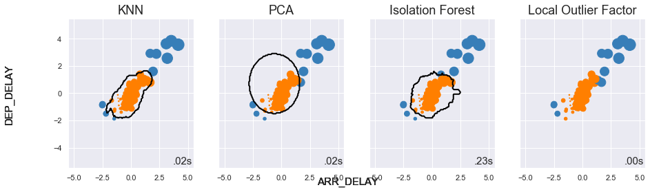

```python
# Utilise:  !pip install pyod
# pour installer le package pyod.

matplotlib.rcParams['contour.negative_linestyle'] = 'solid'
warnings.filterwarnings("ignore")

# donnée normalisée pour les méthodes
X= pd.DataFrame(preprocessing.scale(Newdata[['ARR_DELAY','DEP_DELAY']]))

# définir les méthodes de détection des valeurs aberrantes/anomalies à comparer
anomaly_algorithms = [
    ("KNN", KNN()),
    ("PCA", PCA(random_state=42)),
    ("Isolation Forest", IsolationForest(behaviour='new',
                                         random_state=42)),
    ("Local Outlier Factor", LocalOutlierFactor(
        n_neighbors=35))]

# Compare given classifiers under given settings
xx, yy = np.meshgrid(np.linspace(-5, 5, 150),
                     np.linspace(-5, 5, 150))

# Definition des variables
dataa=Newdata  # la donnée non normalisée.
rng = np.random.RandomState(42)
i_dataset=0  # variable intermédiare
fig, ax = plt.subplots(1, 4, sharex=True, sharey=True,figsize=(15,4))
nu=0   # variable intermédiare
plot_num = 1 ## index pour les figures
pre=pd.DataFrame([]) ## pre is data frame containing predictions for ALL the 4 methods
pred=pd.DataFrame([]) ## pred contains predictions for each method

for name, algorithm in anomaly_algorithms:
    t0 = time.time()
    algorithm.fit(X)
    t1 = time.time()
    if i_dataset == 0:
        ax[plot_num-1].set_title(name, size=18)

    # fit the data and tag outliers
    if name == "Local Outlier Factor":
        y_pred = algorithm.fit_predict(X)
    else:
        y_pred = algorithm.fit(X).predict(X)
    if name in ["PCA","KNN"]:
        y_pred=np.reshape([1 if x==0 else -1 for x in y_pred],-1) # map 0 to 1, 1to -1 and reshape it to 1D array
    #   Looking at what they have in common
    predy= dataa[y_pred==-1].iloc[:,0]   # take the prediction for countries marked as outlier
    if nu == 1:
        pred= list(set(predy)& set(pred))  ## common cities selected by the previous and current methods
    if nu==0:   # varibale factice pour vérifier si nous sommes entrés dans la boucle au moins une fois (nu=1) else (nu=0)
        pred=predy
    if name in ["KNN"]:
        print("\n Aéroports sélectionnés comme aberrants par ",name,'\n',pd.DataFrame(predy))
    else: print("\n Aéroports sélectionnés comme aberrants par ",name,'\n\n',pd.DataFrame(predy,columns=['DEST_CITY_NAME']))
    #print('aldo',nu,'\n',predy,'\n')
    nu=1
    # tracer les lignes de niveaux et les points
    if name != "Local Outlier Factor":  # LOF does not implement predict
        Z = algorithm.predict(np.c_[xx.ravel(), yy.ravel()])
        Z = Z.reshape(xx.shape)
        ax[plot_num-1].contour(xx, yy, Z, levels=[0], linewidths=2, colors='black')

    colors = np.array(['#377eb8', '#ff7f00'])
    ax[plot_num-1].scatter(X.iloc[:, 0], X.iloc[:, 1], s=5*data["ARR_DELAY"].abs(),color=colors[(y_pred + 1) // 2])
    fig.text(0.5, 0.04, 'ARR_DELAY', size=15, ha='center')
    fig.text(0.04, 0.5, 'DEP_DELAY', size=15,va='center', rotation='vertical')
    ax[plot_num-1].text(.99, .01, ('%.2fs' % (t1 - t0)).lstrip('0'), verticalalignment='bottom', size=15,
            transform=ax[plot_num-1].transAxes, horizontalalignment='right')
    plot_num += 1
    pre[name]=y_pred
print('\n\n Les aéroports sélectionnés comme valeurs aberrants par toutes les méthodes sont :\n')
print(pred,'\n')

plt.savefig('vols1.png',dpi=200)
plt.show()
```

# Inspection visuelle des villes sélectionnées comme aberrantes par chaque méthode.

## Commentaires

Rappelons que les anomalies sont des vols dont le **temps moyen d'arrivée est supérieur à 15 minutes**. Dans la figure precedente, les cercles **oranges** représentent les aéroports **sans comportement anormal**, tandis que les cercles **blues** représentent les aéroports avec un **comportement anormal** et la *taille* des boules indique les **retards à l'arrivée**. En outre, on constate que , certains aéroports sont identifiés comme aberrants par toutes les méthodes : **Eagle, San Francisco, Marquette, Anchorage**, entre autres. Cependant, des retards chroniques se sont produits à **Marquette (avec 58 minutes de retard en moyenne) prèsque une heure de retard, à Anchorage (avec 51 minutes), à Jackson et Eagle ( ~ 47 minutes)**. Les vols qui sont arrivés plus tôt que l'heure prévue sont indiqués par des **nombres négatifs**, mais ils sont identifiés comme aberrants par presque toutes les méthodes :**Kalispell (-4 minutes), Oakland (-15 minutes), Ontario (-15 minutes) et Burbank (-12 minutes)**, en d'autres termes, ils sont arrivés en moyenne 4, 15 , 15 et 12 minutes plus tôt que l'heure prévue mais ils sont faussement classés comme aberrants. Seul **Kalispell** n'est pas classé comme tel par le LOF.

```python
print('\n For Isolation forest\n')
print(data[pre['Isolation Forest']==-1][['DEST_CITY_NAME','ARR_DELAY','lat','lon']],'\n')
print('\n For PCA\n')
print(data[pre['PCA']==-1][['DEST_CITY_NAME','ARR_DELAY','lat','lon']],'\n')
print('\n For Knn\n')
print(data[pre['KNN']==-1][['DEST_CITY_NAME','ARR_DELAY','lat','lon']],'\n')
print('\n For LOF\n')
print(data[pre['Local Outlier Factor']==-1][['DEST_CITY_NAME','ARR_DELAY','lat','lon']],'\n')
```

```
 For Isolation forest

       DEST_CITY_NAME  ARR_DELAY        lat         lon
3       Anchorage, AK  51.500000  61.216313 -149.894852
14        Burbank, CA -12.000000  34.181648 -118.325855
33         Duluth, MN  31.000000  46.772932  -92.125122
34          Eagle, CO  46.675676  39.616112 -106.717284
49        Jackson, WY  47.694444  43.479965 -110.761815
51        Kahului, HI  21.142857  20.874771 -156.452983
53      Kalispell, MT  -4.000000  48.202256 -114.316712
59      Lexington, KY  33.800000  38.046407  -84.497039
65      Marquette, MI  58.285714  46.448152  -87.630590
76        Oakland, CA -15.333333  44.452164  -64.355164
78        Ontario, CA -15.500000  34.040000 -117.610000
94  San Francisco, CA  37.088785  37.779026 -122.419906
```

[output cut: 50 more lines]

## Nuage de points des villes identifiées comme aberrantes par les algorithmes.

[ go back to the top ]

Pour se faire, on a coloré les villes en fonction des résultats de la methode correspondante. La **couleur bleue** indique les vols qui présentent plus de retard et la **couleur orange** indique les vols qui arrivent à temps.

## 1: PCA

```python
data['text'] = data['DEST_CITY_NAME'] + ', ' + 'ARR_DELAY:' + data['ARR_DELAY'].round(1).astype(str)

# Add scattergeo globe map of volcano locations
fig = go.Figure(data= go.Scattergeo(
              lat=data["lat"],
              lon=data["lon"],
              mode="markers",
              hovertext="text",
              showlegend=False,
              marker=dict(color="crimson", size=4, opacity=0.8)))


colors = np.array(['#377eb8', '#ff7f00'])    # couleurs
fig = go.Figure(data=go.Scattergeo(
        lat=data["lat"],
        lon=data["lon"],
    #locations=data["DEST_CITY_NAME"],
    locationmode = 'USA-states',
        text = data['text'],
        mode = 'markers',
#showlegend = True,
    marker = dict(
            #size = 8,
            size =data["ARR_DELAY"].abs(),
            opacity = 0.8,
            reversescale = True,
            autocolorscale = True,
            symbol = 'circle',
            line = dict(
                width=1,
                color='rgba(102, 102, 102)'
            ),
            colorscale = 'Jet',
            cmin = 0,
            color = colors[(pre['PCA']+1)//2],  # couleurs
            cmax = data["ARR_DELAY"].abs().max(),
            #colorbar_title="leg",
        #showscale=True
        )))

fig.update_layout(
        title = 'Aéroports détectés comme aberrants (avec un delai de retard trés élevé à l\'arrivée)',
        geo = dict(showcountries = True,
            scope = 'usa',
           # projection_type='natural earth',
            showland = True,
            landcolor = "rgb(250, 250, 250)",
            subunitcolor = "black",#"rgb(217, 217, 217)",
            countrycolor = "black",#"rgb(217, 217, 217)",
            countrywidth = .9,
            subunitwidth = .9
        ),
    )
fig.show()
```

[interactive chart not shown]

## 2: Isolation Forest

```python
data['text'] = data['DEST_CITY_NAME'] + ', ' + 'ARR_DELAY:' + data['ARR_DELAY'].round(1).astype(str)

# Add scattergeo globe map of volcano locations
fig = go.Figure(data= go.Scattergeo(
              lat=data["lat"],
              lon=data["lon"],
              mode="markers",
              hovertext="text",
              showlegend=False,
              marker=dict(color="crimson", size=4, opacity=0.8)))


colors = np.array(['#377eb8', '#ff7f00'])    # couleurs
fig = go.Figure(data=go.Scattergeo(
        lat=data["lat"],
        lon=data["lon"],
    locationmode = 'USA-states',
        text = data['text'],
        mode = 'markers',
#showlegend = True,
    marker = dict(
            #size = 8,
            size =data["ARR_DELAY"].abs(),
            opacity = 0.8,
            reversescale = True,
            autocolorscale = True,
            symbol = 'circle',
            line = dict(
                width=1,
                color='rgba(102, 102, 102)'
            ),
            colorscale = 'Jet',
            cmin = 0,
            color = colors[(pre['Isolation Forest']+1)//2],  # couleurs
            cmax = data["ARR_DELAY"].abs().max(),
            #colorbar_title="leg",
        #showscale=True
        )))

fig.update_layout(
        title = 'Aéroports détectés comme aberrants (avec un delai de retard trés élevé à l\'arrivée)',
        geo = dict(showcountries = True,
            scope = 'usa',
           # projection_type='natural earth',
            showland = True,
            landcolor = "rgb(250, 250, 250)",
            subunitcolor = "black",#"rgb(217, 217, 217)",
            countrycolor = "black",#"rgb(217, 217, 217)",
            countrywidth = .9,
            subunitwidth = .9
        ),
    )
fig.show()
```

[interactive chart not shown]

## 3: KNN

```python
data['text'] = data['DEST_CITY_NAME'] + ', ' + 'ARR_DELAY:' + data['ARR_DELAY'].round(1).astype(str)

# Add scattergeo globe map of volcano locations
fig = go.Figure(data= go.Scattergeo(
              lat=data["lat"],
              lon=data["lon"],
              mode="markers",
              hovertext="text",
              showlegend=False,
              marker=dict(color="crimson", size=4, opacity=0.8)))


colors = np.array(['#377eb8', '#ff7f00'])    # couleurs
fig = go.Figure(data=go.Scattergeo(
        lat=data["lat"],
        lon=data["lon"],
    #locations=data["DEST_CITY_NAME"],
    locationmode = 'USA-states',
        text = data['text'],
        mode = 'markers',
#showlegend = True,
    marker = dict(
            #size = 8,
            size =data["ARR_DELAY"].abs(),
            opacity = 0.8,
            reversescale = True,
            autocolorscale = True,
            symbol = 'circle',
            line = dict(
                width=1,
                color='rgba(102, 102, 102)'
            ),
            colorscale = 'Jet',
            cmin = 0,
            color = colors[(pre['KNN']+1)//2],  # couleurs
            cmax = data["ARR_DELAY"].abs().max(),
            #colorbar_title="leg",
        #showscale=True
        )))

#"Isolation Forest"
#"Local Outlier Factor"
fig.update_layout(
        title = 'Aéroports détectés comme aberrants (avec un delai de retard trés élevé à l\'arrivée)',
        geo = dict(showcountries = True,
            scope = 'usa',
           # projection_type='natural earth',
            showland = True,
            landcolor = "rgb(250, 250, 250)",
            subunitcolor = "black",#"rgb(217, 217, 217)",
            countrycolor = "black",#"rgb(217, 217, 217)",
            countrywidth = .9,
            subunitwidth = .9
        ),
    )
fig.show()
```

[interactive chart not shown]

## 4: Local Outlier Factor

```python
data['text'] = data['DEST_CITY_NAME'] + ', ' + 'ARR_DELAY:' + data['ARR_DELAY'].round(1).astype(str)

# Ajout d'une carte des emplacements des volcans sur le globe scattergeo
fig = go.Figure(data= go.Scattergeo(
              lat=data["lat"],
              lon=data["lon"],
              mode="markers",
              hovertext="text",
              showlegend=False,
              marker=dict(color="crimson", size=4, opacity=0.8)))


colors = np.array(['#377eb8', '#ff7f00'])    # couleurs
fig = go.Figure(data=go.Scattergeo(
        lat=data["lat"],
        lon=data["lon"],
    #locations=data["DEST_CITY_NAME"],
    locationmode = 'USA-states',
        text = data['text'],
        mode = 'markers',
#showlegend = True,
    marker = dict(
            #size = 8,
            size =data["ARR_DELAY"].abs(),
            opacity = 0.8,
            reversescale = True,
            autocolorscale = True,
            symbol = 'circle',
            line = dict(
                width=1,
                color='rgba(102, 102, 102)'
            ),
            colorscale = 'Jet',
            cmin = 0,
            color = colors[(pre['Local Outlier Factor']+1)//2],  # couleurs
            cmax = data["ARR_DELAY"].abs().max(),
            #colorbar_title="leg",
           #showscale=True
        )))


fig.update_layout(
        title = 'Aéroports détectés comme aberrants (avec un delai de retard trés élevé à l\'arrivée)',
        geo = dict(showcountries = True,
            scope = 'usa',
           # projection_type='natural earth',
            showland = True,
            landcolor = "rgb(250, 250, 250)",
            subunitcolor = "black",#"rgb(217, 217, 217)",
            countrycolor = "black",#"rgb(217, 217, 217)",
            countrywidth = .9,
            subunitwidth = .9
        ),
    )
fig.show()
```

[interactive chart not shown]

## Dataset 2: Distracted driving fatality data

[ go back to the top ]

La distraction au volant comprend toute activité qui pourrait détourner l'attention d'une personne de la tâche principale de conduire, comme **envoyer des messages textes, utiliser un téléphone cellulaire, manger et boire, faire sa toilette, utiliser un système de navigation, régler une radio, etc.**

Les décès figurant dans ce tableau ne concernent que les occupants de voitures et de camions légers. Les occupants d'autres types de véhicules - camions lourds, motocyclettes et autobus - sont exclus, tout comme les autres types de décès sur la route, comme les décès de piétons.

```python
import seaborn as sns
import plotly.offline as py
import plotly.graph_objs as go
color = sns.color_palette()
sns.set(style="darkgrid")
Fatdata = pd.read_csv('Fatal_acc_field_table_data_und_0.csv')
print(Fatdata.head())  #
print('La dimension est',Fatdata.shape)   # la dimension
```

```
        State  Restraint_used_Fatalities  No_restraint_used_Fatalities  \
0     Alabama                        271                           369
1      Alaska                         13                            12
2     Arizona                        175                           227
3    Arkansas                        135                           174
4  California                        986                           500

   No_restraint_used_Percent  Restraint_use_unknown_Fatalities  \
0                       55.0                                25
1                       44.0                                 2
2                       50.0                                49
3                       51.0                                31
4                       31.0                               125

   Restraint_use_unknown_Percent
0                            4.0
1                            7.0
2                           11.0
3                            9.0
4                            8.0
La dimension est (51, 6)
```

Les variables *No_restraint_used_Percent* et *Restraint_use_unknown_Percent* ont été enlevées avant de les passer aux algorithmes car elles sont redondantes.

```python
# Supprimer les variables non utilisées
Fatdata1=Fatdata.drop([
       'No_restraint_used_Percent',
       'Restraint_use_unknown_Percent'],axis=1)
print(Fatdata1.head())
```

```
        State  Restraint_used_Fatalities  No_restraint_used_Fatalities  \
0     Alabama                        271                           369
1      Alaska                         13                            12
2     Arizona                        175                           227
3    Arkansas                        135                           174
4  California                        986                           500

   Restraint_use_unknown_Fatalities
0                                25
1                                 2
2                                49
3                                31
4                               125
```

Nuage de points montrant relation entre *Restraint_used_Fatalities* et *No_restraint_used_Fatalities* avec *Restraint_used_Fatalities* comme taille des bulles.

Une analyse visuelle de la Figure de cette figure, montre qu'il y a des pays qui se distinguent des autres avec un nombre élevé d'accidents mortels dans ces pays. Il serait intéréssant de connaitre ces pays. La figure suivante donne un peu plus de details sur ces pays.

```python
import plotly.express as px
px.scatter(Fatdata1, x='Restraint_used_Fatalities', y='No_restraint_used_Fatalities',
           size='Restraint_used_Fatalities',# color='State',
           width=900, height=400,
           title = "Relation entre Restraint_used_Fatalities et No_restraint_used_Fatalities avec Restraint_used_Fatalities comme taille des bulles")
```

[interactive chart not shown]

### Nuage de points montrant relation entre *Restraint_used_Fatalities* et *No_restraint_used_Fatalities* avec *Restraint_used_Fatalities* comme taille des bulles ainsi que la boite à moustaches de chaque variable.

Une analyse visuelle de la Figure, montre qu'il y a des pays qui se distinguent des autres avec un nombre élevé d'accidents mortels dans ces pays. D'autre part, la boîte à moustaches, nous indique également que ces pays sont anormaux (aberrants), ces pays sont **Texas, california, Florida**. Une analyse plus approfondie est menée pour corroborer les résultats antérieurs. Ces méthodes sont **KNN, PCA, LOF and Isolation Forest**.

```python
 fig = px.scatter(Fatdata1, x='Restraint_used_Fatalities', y='No_restraint_used_Fatalities', marginal_y="box",
           marginal_x="box", text=Fatdata1['State'],trendline="ols")
fig.show()
```

[interactive chart not shown]

## Extraction des coordonnées de chaque pays

[ go back to the top ]

```python
data1 = Fatdata1.copy()

key = 'de4f24290886448da691eb368c1cb52b'
geocoder = OpenCageGeocode(key)
list_lat = []   # create empty lists
list_long = []
for index, row in data1.iterrows(): # iterate over rows in dataframe
    City = row['State']
    query = str(City)
    results = geocoder.geocode(query)
    lat = results[0]['geometry']['lat']
    long = results[0]['geometry']['lng']
    print(query,lat,long)
    list_lat.append(lat)
    list_long.append(long)
# create new columns from lists
data1['lat'] = list_lat
data1['lon'] = list_long
data1.head()
#np.savetxt('AB_data.txt', data1)
```

```
Alabama 33.2588817 -86.8295337
Alaska 64.4459613 -149.680909
Arizona 34.395342 -111.7632755
Arkansas 35.2048883 -92.4479108
California 36.7014631 -118.7559974
Colorado 38.7251776 -105.6077167
Connecticut 41.6500201 -72.7342163
Delaware 38.6920451 -75.4013315
District of Columbia 38.8936613 -76.9878833
Florida 27.7567667 -81.4639835
Georgia 41.6809707 44.0287382
Hawaii 21.2160437 -157.975203
Idaho 43.6447642 -114.0154071
Illinois 40.0796606 -89.4337288
Indiana 40.3270127 -86.1746933
Iowa 41.9216734 -93.3122705
Kansas 38.27312 -98.5821872
Kentucky 37.5726028 -85.1551411
Louisiana 30.8703881 -92.007126
Maine 45.709097 -68.8590201
Maryland 39.5162234 -76.9382069
Massachusetts 42.3788774 -72.032366
Michigan 43.6211955 -84.6824346
Minnesota 45.9896587 -94.6113288
Mississippi 32.9715645 -89.7348497
Missouri 38.7604815 -92.5617875
Montana 47.3752671 -109.6387579
Nebraska 41.7370229 -99.5873816
Nevada 39.5158825 -116.8537227
New Hampshire 43.4849133 -71.6553992
New Jersey 40.0757384 -74.4041622
New Mexico 34.5708167 -105.993007
New York 40.7127281 -74.0060152
North Carolina 35.6729639 -79.0392919
North Dakota 47.6201461 -100.540737
Ohio 40.2253569 -82.6881395
Oklahoma 34.9550817 -97.2684063
Oregon 43.9792797 -120.737257
Pennsylvania 40.9699889 -77.7278831
Rhode Island 41.7962409 -71.5992372
South Carolina 33.6874388 -80.4363743
South Dakota 44.6471761 -100.348761
Tennessee 35.7730076 -86.2820081
Texas 31.8160381 -99.5120986
Utah 39.4225192 -111.7143584
Vermont 44.5990718 -72.5002608
Virginia 37.1232245 -78.4927721
Washington 38.8949855 -77.0365708
West Virginia 38.4758406 -80.8408415
Wisconsin 44.4308975 -89.6884637
Wyoming 43.1700264 -107.5685348
```

|  | State | Restraint_used_Fatalities | No_restraint_used_Fatalities | Restraint_use_unknown_Fatalities | lat | lon |
| --- | --- | --- | --- | --- | --- | --- |
| 0 | Alabama | 271 | 369 | 25 | 33.258882 | -86.829534 |
| 1 | Alaska | 13 | 12 | 2 | 64.445961 | -149.680909 |
| 2 | Arizona | 175 | 227 | 49 | 34.395342 | -111.763276 |
| 3 | Arkansas | 135 | 174 | 31 | 35.204888 | -92.447911 |
| 4 | California | 986 | 500 | 125 | 36.701463 | -118.755997 |

## Nuage de points des accidents mortels sur la carte

[ go back to the top ]

```python
data=data1.copy()
# Add scattergeo globe map of volcano locations
fig = go.Figure(data= go.Scattergeo(
              lat=data["lat"],
              lon=data["lon"],
              mode="markers",
              hoverinfo="text",
              showlegend=False,
              marker=dict(color="crimson", size=3, opacity=0.8)))



fig = go.Figure(data=go.Scattergeo(
        lat=data["lat"],
        lon=data["lon"],
        text =  data['State'] + ', ' + 'Restraint_used_Fat:' + data['Restraint_used_Fatalities'].astype(str) + ', ' + 'No_restraint_used_Fat:' + data['No_restraint_used_Fatalities'].astype(str) ,#data['text'],
        mode = 'markers',
        marker = dict(
            #size = 8,
            size =data["Restraint_used_Fatalities"].abs()/20,
            opacity = 0.8,
            reversescale = True,
            autocolorscale = True,
            symbol = 'circle',
            line = dict(
                width=1,
                color='rgba(102, 102, 102)'
            ),
            colorscale = 'Blues',
            cmin = 0,
            color = data["Restraint_used_Fatalities"].abs(), #data['GDP.Per.Capita..thousands....PPP.rates..per.resident.'],
            cmax = data["Restraint_used_Fatalities"].abs().max()
            #colorbar_title="GDP"
        )))

fig.update_layout(
        title = ' Nuage de points des accidents mortels sur la carte avec Restraint_used_Fatalities comme taille des cercles',
        geo = dict(
            projection_type='equirectangular',#'natural earth',
            showland = True,
            landcolor = "rgb(250, 250, 250)",
            subunitcolor = "rgb(217, 217, 217)",
            countrycolor = "rgb(217, 217, 217)",
            countrywidth = 0.8,
            subunitwidth = 0.8
        ),
    )
fig.show()
```

[interactive chart not shown]

Cette figure indique encore que **Texas, california, Florida** se distinguent des autres de feçon significative.

Cliquez sur l'image pour faire un zoom avant et arrière

```python
# Normalisation de vos données avant la transformation
Fatdata1[['Restraint_used_Fatalities','No_restraint_used_Fatalities']]=preprocessing.scale(Fatdata1[['Restraint_used_Fatalities','No_restraint_used_Fatalities']])
```

## Application d'algorithmes de détection de valeurs aberrantes

[ go back to the top ]

```
 Pays sélectionnés comme aberrants par  KNN
              State
4       California
9          Florida
33  North Carolina
43           Texas

 Pays sélectionnés comme aberrants par  PCA
         State
0     Florida
1       Texas
2  California

 Pays sélectionnés comme aberrants par  Isolation Forest
         State
0     Florida
1       Texas
2  California

 Pays sélectionnés comme aberrants par  Local Outlier Factor
         State
0     Florida
1       Texas
2  California


Pays sélectionnés comme aberrants par toutes les méthodes  sont :

['Florida', 'Texas', 'California']
```

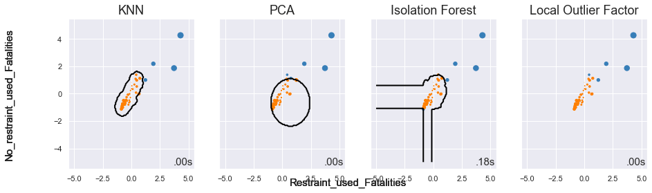

```python
matplotlib.rcParams['contour.negative_linestyle'] = 'solid'

warnings.filterwarnings("ignore")

# donnée normalisée pour les méthodes
X= pd.DataFrame(Fatdata1[['Restraint_used_Fatalities','No_restraint_used_Fatalities']])

# définir les méthodes de détection des valeurs aberrantes/anomalies à comparer
anomaly_algorithms = [
    ("KNN", KNN()),
    ("PCA", PCA(random_state=42)),
    ("Isolation Forest", IsolationForest(behaviour='new',
                                         random_state=42)),
    ("Local Outlier Factor", LocalOutlierFactor(
        n_neighbors=35))]

# Compare given classifiers under given settings
xx, yy = np.meshgrid(np.linspace(-5, 5, 150),
                     np.linspace(-5, 5, 150))

# Definition des variables
data=Fatdata1 # la donnée non normalisée.
rng = np.random.RandomState(42)
i_dataset=0  # variable intermédiare
fig, ax = plt.subplots(1, 4, sharex=True, sharey=True,figsize=(15,4))
nu=0   # variable intermédiare
plot_num = 1 ## index pour les figures
pre=pd.DataFrame([]) ## pre est un cadre de données contenant des prédictions pour TOUTES les 4 méthodess
pred=pd.DataFrame([]) ## pred contient des prédictions pour chaque méthode


for name, algorithm in anomaly_algorithms:
    t0 = time.time()
    algorithm.fit(X)
    t1 = time.time()
    if i_dataset == 0:
        ax[plot_num-1].set_title(name, size=18)

    # fit the data and tag outliers
    if name == "Local Outlier Factor":
        y_pred = algorithm.fit_predict(X)
    else:
        y_pred = algorithm.fit(X).predict(X)
    if name in ["PCA","KNN"]:
        y_pred=np.reshape([1 if x==0 else -1 for x in y_pred],-1) # map 0 to 1, 1to -1 and reshape it to 1D array

#   Looking at what they have in common
    predy= data[y_pred==-1].iloc[:,0]   # take the prediction for countries
    if name in ["PCA","KNN"]:
        predy= data[y_pred==-1].iloc[:,0] # PCA puts label 1 for oultier, then
    if nu == 1:
        pred= list(set(predy)& set(pred))
    if nu==0:
        pred=predy
    if name in ["KNN"]:
        print("\n Pays sélectionnés comme aberrants par ",name,'\n',pd.DataFrame(pred))
    else: print("\n Pays sélectionnés comme aberrants par ",name,'\n',pd.DataFrame(pred,columns=['State']))
    nu=1
    # tracer les lignes de niveaux et les points
    if name != "Local Outlier Factor":  # LOF does not implement predict
        Z = algorithm.predict(np.c_[xx.ravel(), yy.ravel()])
        Z = Z.reshape(xx.shape)
        ax[plot_num-1].contour(xx, yy, Z, levels=[0], linewidths=2, colors='black')
    colors = np.array(['#377eb8', '#ff7f00'])
    ax[plot_num-1].scatter(X.iloc[:, 0], X.iloc[:, 1], s=15*data["Restraint_used_Fatalities"].abs(),color=colors[(y_pred + 1) // 2])
    fig.text(0.5, 0.04, X.columns[0], size=15, ha='center')
    fig.text(0.04, 0.5, X.columns[1], size=15,va='center', rotation='vertical')
    ax[plot_num-1].text(.99, .01, ('%.2fs' % (t1 - t0)).lstrip('0'), verticalalignment='bottom', size=15,
            transform=ax[plot_num-1].transAxes, horizontalalignment='right')
    plot_num += 1
    pre[name]=y_pred
print('\n\nPays sélectionnés comme aberrants par toutes les méthodes  sont :\n')
print(pred,'\n')

plt.savefig('Fatalall.png',dpi=200)
plt.show()
```

De ces figures, on peut voir les pays aberrants tels que détectés par les différentes techniques autrement dit, les pays qui enregistrent plus d'accidents. Les **points oranges** représentent les pays sans comportement aberrant (moins ou presque pas d'accidents).

En effet, **Texas et california** peuvent être considérés comme **pays aberrants global** ou les il y a plus d'accidents que dans les autres pays. Les conducteurs sont, la plus part du temps, moins concentrés au volant et plus occcupés à **envoyer des messages textes, utiliser un téléphone cellulaire, manger et boire, faire sa toilette, utiliser un système de navigation, régler une radio, etc.** que de donner une attention particulière à la conduite.

Par ailleurs **Florida et Carolina** peuvent être cosidérés comme **pays aberrants locaux**.

## Nuage de points des accidents mortels sur la carte avec comme couleur les résultats de Isolation Forest.

[ go back to the top ]

Les **cercles oranges** représentent les pays sans comportement aberrant, tandis que les **cercles bleus** représentent ceux avec un comportement aberrant avec **Restraint_used_Fatalities comme taille des cercles**.

```python
import plotly.graph_objects as go
data=data1.copy()

data[pre.columns]=pre
# Add scattergeo globe map of volcano locations
fig = go.Figure(data= go.Scattergeo(
              lat=data["lat"],
              lon=data["lon"],
              mode="markers",
              hoverinfo="text",
              showlegend=False,
              marker=dict(color="crimson", size=3, opacity=0.8)))



colors = np.array(['#377eb8', '#ff7f00'])
#colors= ['red' if l == 0 else 'blue' for l in data['PCA']]
fig = go.Figure(data=go.Scattergeo(
        lat=data["lat"],
        lon=data["lon"],
        text = data['State'] + ', ' + 'Restraint_used_Fat:' + data['Restraint_used_Fatalities'].astype(str) + ', ' + 'No_restraint_used_Fat:' + data['No_restraint_used_Fatalities'].astype(str),#data['text'],
        mode = 'markers',
        marker = dict(
            #size = 8,
            size =data["Restraint_used_Fatalities"].abs()/20,
            opacity = 0.8,
            reversescale = True,
            autocolorscale = True,
            symbol = 'circle',
            line = dict(
                width=1,
                color='rgba(102, 102, 102)'
            ),
            colorscale = 'Blues',
            cmin = 0,
            color = colors[(pre['Isolation Forest']+1)//2],#data["Restraint_used_Fatalities"].abs(), #data['GDP.Per.Capita..thousands....PPP.rates..per.resident.'],
            cmax = data["Restraint_used_Fatalities"].abs().max(),
            #colorbar_title="GDP"
        )))



fig.update_layout(
        title = 'Nuage de points des accidents mortels sur la carte avec Restraint_used_Fatalities comme taille des cercles',
        geo = dict(
            projection_type='equirectangular',#'natural earth',
            showland = True,
            landcolor = "rgb(250, 250, 250)",
            subunitcolor = "rgb(217, 217, 217)",
            countrycolor = "rgb(217, 217, 217)",
            countrywidth = 0.8,
            subunitwidth = 0.8
        ),
    )
fig.show()
```

[interactive chart not shown]

### Nuage de points pour chaque algorithme

```python
import plotly.express as px
px.scatter(Fatdata, x='Restraint_used_Fatalities', y='No_restraint_used_Fatalities',text=Fatdata1['State'],
           size='Restraint_used_Fatalities', color=-1*pre.iloc[:,0], width=900, height=400,title = "KNN")
```

[interactive chart not shown]

```python
px.scatter(Fatdata, x='Restraint_used_Fatalities', y='No_restraint_used_Fatalities',text=Fatdata1['State'],
           size='Restraint_used_Fatalities', color=-1*pre.iloc[:,1], width=900, height=400,#text=df['State'],
           title = "PCA")
```

[interactive chart not shown]

```python
px.scatter(Fatdata, x='Restraint_used_Fatalities', y='No_restraint_used_Fatalities',text=Fatdata1['State'],
           size='Restraint_used_Fatalities', color=pre.iloc[:,2], width=900, height=400,#text=df['State'],
           title = "IsolationForest")
```

[interactive chart not shown]

```python
px.scatter(Fatdata, x='Restraint_used_Fatalities', y='No_restraint_used_Fatalities',text=Fatdata1['State'],
           size='Restraint_used_Fatalities', color=pre.iloc[:,3], width=900, height=400,#text=df['State'],
           title = "Local Outlier Factor")
```

[interactive chart not shown]

## Dataset 3: House prices data

[ go back to the top ]

La donnée est disponible dans https://www.kaggle.com/c/house-prices-advanced-regression-techniques/data.

Cette donnée a 1460 observations et 81 d'attributs, dont 36 sont quantitatifs, 43 catégoriques. Les variables sont les suivantes (pour une description complète des variables, se rèfèrer à l'adresse ci-haut)

**Quantitative**: 1stFlrSF, 2ndFlrSF, 3SsnPorch, BedroomAbvGr, BsmtFinSF1, BsmtFinSF2, BsmtFullBath, BsmtHalfBath, BsmtUnfSF, EnclosedPorch, Fireplaces, FullBath, GarageArea, GarageCars, GarageYrBlt, GrLivArea, HalfBath, KitchenAbvGr, LotArea, LotFrontage, LowQualFinSF, MSSubClass, MasVnrArea, MiscVal, MoSold, OpenPorchSF, OverallCond, OverallQual, PoolArea, ScreenPorch, TotRmsAbvGrd, TotalBsmtSF, WoodDeckSF, YearBuilt, YearRemodAdd, YrSold

**Qualitative**: Alley, BldgType, BsmtCond, BsmtExposure, BsmtFinType1, BsmtFinType2, BsmtQual, CentralAir, Condition1, Condition2, Electrical, ExterCond, ExterQual, Exterior1st, Exterior2nd, Fence, FireplaceQu, Foundation, Functional, GarageCond, GarageFinish, GarageQual, GarageType, Heating, HeatingQC, HouseStyle, KitchenQual, LandContour, LandSlope, LotConfig, LotShape, MSZoning, MasVnrType, MiscFeature, Neighborhood, PavedDrive, PoolQC, RoofMatl, RoofStyle, SaleCondition, SaleType, Street, Utilities.

Le prétraitement des données est effectué dans kaggle à l'adresse suivante: https://www.kaggle.com/dgawlik/house-prices-eda.

```python
import matplotlib.pyplot as plt
from sklearn import datasets
import pandas as pd
import numpy as np
data = pd.read_csv("HousePrices.csv")
# take countinuous variables
print('La dimension est',data.shape)
num_continuous = ['Id','LotFrontage','LotArea','MasVnrArea','BsmtFinSF1','BsmtFinSF2','BsmtUnfSF','TotalBsmtSF','1stFlrSF',
                  '2ndFlrSF','LowQualFinSF','GrLivArea','GarageArea','WoodDeckSF','OpenPorchSF','EnclosedPorch',
                  '3SsnPorch','ScreenPorch','PoolArea','MiscVal','SalePrice','SaleCondition']
HouseNum=data[num_continuous]      # prendre les variables qui nous interessent.
House=HouseNum.dropna(axis = 0)  # Enlever NAs
House[House.isnull().any(axis=1)]   # verifier s'il y a des NAs
print('\nApres le prétraitement la dimension est',House.shape)
```

```
La dimension est (1460, 81)

Apres le prétraitement la dimension est (1195, 22)
```

## Nuage de points 2D et en 3D

[ go back to the top ]

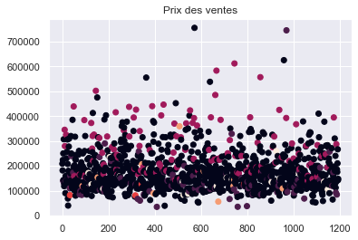

```python
# Generer les couleurs pour les variables qualitatives
colors = {"SaleCondition":    {'Normal':0, 'Abnorml':1, 'Partial':2, 'AdjLand':3, 'Alloca':4, 'Family':5} }
House.replace(colors, inplace=True)
House['SaleCondition']=House['SaleCondition'].astype('category')
plt.scatter(range(0,(len(House['SalePrice']))),House['SalePrice'], c=House['SaleCondition'])
plt.title('Prix des ventes')
plt.show()
```

Le nuage de points des prix des ventes a des caractéristiques variables, on a des prix extrèmes: très élévés (plus de 600 000 US pour uen maison) ou encore trop faible (40 000 US). Ces prix varient notament en fonction de l'emplacement, le contenu, la superficie, etc. La figure suivante en 3 dimensions nous montre qu'en effet qu'il y a des prix qui s'éloignent des autres. Ils peuvent donc être des points aberrants globaux.

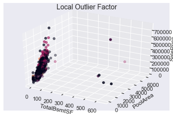

```python
# 3d plot
from mpl_toolkits.mplot3d import Axes3D
fig = plt.figure()
ax = fig.add_subplot(111, projection='3d')
x, y, z=[House['PoolArea'],House['TotalBsmtSF'],House['SalePrice']]
ax.scatter(x, y, z,c=House['SaleCondition'], marker='o',)
ax.set_xlabel("TotalBsmtSF")
ax.set_ylabel("PoolArea")
ax.set_zlabel("SalePrice")
plt.title(name, fontsize=14);
plt.show()
```

Dans cette figure, les varibles **SalePrice**, **PoolArea**: Surface de la piscine en pieds carrés, **TotalBsmtSF**: Superficie totale du sous-sol en pieds carrés. IL y a en effet un lot de prix qui se s'écarte rapidement du reste, donc le prix est proportionnel à la superficie du sous-sol et de la piscine mais aussi des autres parametres.

## Algorithmes de détection: donnée en 2D

[ go back to the top ]

```
Liste des numeros (ID) des éléments sélectionnés comme aberrants par toutes les méthodes  sont

[384, 770, 899, 265, 528, 1170, 916, 917, 534, 1047, 1433, 411, 30, 1183, 31, 799, 804, 813, 1326, 179, 692, 441, 186, 59, 1338, 706, 711, 969, 1101, 463, 592, 474, 350, 1381, 615, 875, 496, 637]
```

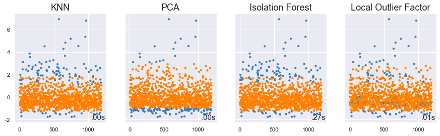

```python
matplotlib.rcParams['contour.negative_linestyle'] = 'solid'

warnings.filterwarnings("ignore")
from sklearn import preprocessing

# Define datasets 2
X= pd.DataFrame(preprocessing.scale(House['SalePrice']).reshape(-1, 1))

# définir les méthodes de détection des valeurs aberrantes/anomalies à comparer
anomaly_algorithms = [
    ("KNN", KNN()),
    ("PCA", PCA(random_state=42)),
    ("Isolation Forest", IsolationForest(behaviour='new',
                                         random_state=42)),
    ("Local Outlier Factor", LocalOutlierFactor(
        n_neighbors=35))]

# Compare given classifiers under given settings
xx, yy = np.meshgrid(np.linspace(-5, 5, 150),
                     np.linspace(-5, 5, 150))

# Definition des variables
rng = np.random.RandomState(42)
i_dataset=0  # variable intermédiare
fig, ax = plt.subplots(1, 4, sharex=True, sharey=True,figsize=(15,4))
nu=0   # variable intermédiare
plot_num = 1 ## index pour les figures
pre=pd.DataFrame([]) ## pre est un cadre de données contenant des prédictions pour TOUTES les 4 méthodess
pred=pd.DataFrame([]) ## pred contient des prédictions pour chaque méthode

for name, algorithm in anomaly_algorithms:
    t0 = time.time()
    algorithm.fit(X)
    t1 = time.time()
    if i_dataset == 0:
        ax[plot_num-1].set_title(name, size=18)

    # fit the data and tag outliers
    if name == "Local Outlier Factor":
        y_pred = algorithm.fit_predict(X)
    else:
        y_pred = algorithm.fit(X).predict(X)

    if name in ["PCA","KNN"]:
        y_pred=np.reshape([1 if x==0 else -1 for x in y_pred],-1) # map 0 to 1, 1to -1 and reshape it to 1D array


#   Looking at what they have in common
    predy= House[y_pred==-1]['Id']   # take the prediction for countries
    if name in ["PCA","KNN"]:
        predy= House[y_pred==-1]["Id"] # PCA puts label 1 for oultier, then

    if nu == 1:
        pred= list(set(predy)& set(pred))
    if nu==0:
        pred=predy
    nu=1
    colors = np.array(['#377eb8', '#ff7f00'])
    y_pred[y_pred==0]=-1
    #y_pred.sort()
    ax[plot_num-1].scatter(X.index,X, s=10,color=colors[(y_pred + 1) // 2])
    ax[plot_num-1].text(.99, .01, ('%.2fs' % (t1 - t0)).lstrip('0'), verticalalignment='bottom', size=15,
            transform=ax[plot_num-1].transAxes, horizontalalignment='right')
    plot_num += 1
    pre[name]=y_pred
print('Liste des numeros (ID) des éléments sélectionnés comme aberrants par toutes les méthodes  sont \n')
print(pred,'\n')

#plt.savefig('Fatalall.png',dpi=200)
plt.show()
```

Les **points oranges** représentent les prix normaux dans le marché et donc sans comportement aberrant , tandis que les **points bleus** représentent les prix anormaux (trop cher ou moins cher) dans le marché. Ici, toutes les méthodes parviennetn à capter plus ou moins l'ensemble des prix (trop cher et moins cher).

On a la même observation que dans le graphique en 3 dimensions.

## Algorithmes de détection: donnée en 3D

[ go back to the top ]

```
Liste des éléments sélectionnés comme aberrants par toutes les méthodes  sont

[770, 899, 524, 528, 1170, 1171, 1299, 1045, 1047, 410, 799, 1183, 804, 811, 179, 692, 1206, 441, 186, 59, 198, 71, 711, 1101, 333, 609, 225, 363, 1387, 1143, 889, 637]

La taille est proportionnelle au prix de vente
```

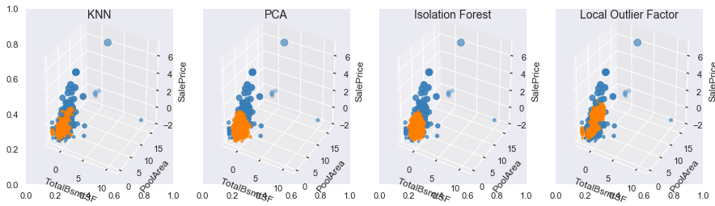

```python
# set up a figure twice as wide as it is tall
fig = plt.figure(figsize=plt.figaspect(0.3))
plt.subplots_adjust(left=.02, right=.98, bottom=.02, top=.96, wspace=.2,
                   hspace=.01)

matplotlib.rcParams['contour.negative_linestyle'] = 'solid'

warnings.filterwarnings("ignore")
from sklearn import preprocessing

# Define datasets 2
X= pd.DataFrame(preprocessing.scale(House[['TotalBsmtSF','PoolArea','SalePrice']]))

# définir les méthodes de détection des valeurs aberrantes/anomalies à comparer
anomaly_algorithms = [
    ("KNN", KNN()),
    ("PCA", PCA(random_state=42)),
    ("Isolation Forest", IsolationForest(behaviour='new',
                                         random_state=42)),
    ("Local Outlier Factor", LocalOutlierFactor(
        n_neighbors=35))]

# Compare given classifiers under given settings
xx, yy = np.meshgrid(np.linspace(-5, 5, 150),
                     np.linspace(-5, 5, 150))

# Definition des variables
rng = np.random.RandomState(42)
i_dataset=0  # variable intermédiare
fig, ax = plt.subplots(1, 4, sharex=True, sharey=True,figsize=(15,4))
nu=0   # variable intermédiare
plot_num = 1 ## index pour les figures
pre=pd.DataFrame([]) ## pre est un cadre de données contenant des prédictions pour TOUTES les 4 méthodess
pred=pd.DataFrame([]) ## pred contient des prédictions pour chaque méthode



for name, algorithm in anomaly_algorithms:
    t0 = time.time()
    algorithm.fit(X)
    t1 = time.time()
      # fit the data and tag outliers
    if name == "Local Outlier Factor":
        y_pred = algorithm.fit_predict(X)
    else:
        y_pred = algorithm.fit(X).predict(X)
    if name in ["PCA","KNN"]:
        y_pred=np.reshape([1 if x==0 else -1 for x in y_pred],-1) # map 0 to 1, 1to -1 and reshape it to 1D array


#   Looking at what they have in common
    predy= House[y_pred==-1]['Id']   # take the prediction for countries
    if name in ["PCA","KNN"]:
        predy= House[y_pred==-1]["Id"] # PCA puts label 1 for oultier, then

    if nu == 1:
        pred= list(set(predy)& set(pred))#[x for x in predy if x in predn]
    if nu==0:
        pred=predy
    #print('aldo',nu,'\n',predy,'\n')
    nu=1
    colors = np.array(['#377eb8', '#ff7f00'])
    y_pred[y_pred==0]=-1
    #y_pred.sort()
    ax = fig.add_subplot(1, 4, plot_num, projection='3d')
    # plot a 3D wireframe like in the example mplot3d/wire3d_demo
    x, y, z=[X.iloc[:,0], X.iloc[:,1], X.iloc[:,2]]
    ax.scatter(x, y, z,color=colors[(y_pred + 1) // 2], marker='o',s=House['SalePrice']/10000)
    ax.set_xlabel("TotalBsmtSF")
    ax.set_ylabel("PoolArea")
    ax.set_zlabel("SalePrice")
    plt.title(name, fontsize=14);
    plot_num += 1
    pre[name]=y_pred#pre.append(y_pred)
print('Liste des éléments sélectionnés comme aberrants par toutes les méthodes  sont \n')
print(pred,'\n')
print('La taille est proportionnelle au prix de vente \n')

#plt.savefig('Fatalall.png',dpi=200)
plt.show()
```

## Dataset 4: Temperature data (meldoune Australia)

[ go back to the top ]

Ce jeu de données décrit les températures minimales quotidiennes sur 10 ans (1981-1990) dans la ville de Melbourne, en Australie. Les unités sont en degrés Celsius et il y a 3 650 observations. La source des données est le Bureau australien de météorologie. On peut la trouver sur le lien suivant https://machinelearningmastery.com/time-series-data-visualization-with-python/

```python
from pandas import read_csv
from matplotlib import pyplot
dataTemp = read_csv('Temp.csv', header=0, index_col=0, parse_dates=True, squeeze=True)
print(dataTemp['Temp'])
#dataOG=pd.DataFrame(dataOG[['Date/Time','Mean Temp (°C)']].dropna(axis=0))
#dataOG.index=dataOG['Date/Time']
```

```
Date
1981-01-01    20.7
1981-01-02    17.9
1981-01-03    18.8
1981-01-04    14.6
1981-01-05    15.8
              ...
1990-12-27    14.0
1990-12-28    13.6
1990-12-29    13.5
1990-12-30    15.7
1990-12-31    13.0
Name: Temp, Length: 3650, dtype: float64
```

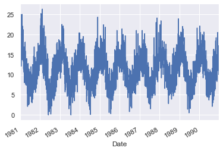

```python
dataTemp['Temp'].plot()
dataTemp['Date']=dataTemp.index
plt.savefig('Temp1.png',dpi=200)
```

## Création d'animations

Avec plotly.express, Il est facile de créer un graphique animé à l'aide de l'argument animation_frame. (https://bookdown.org/jamie/python_visualisation/building-graphs-with-full-control-1.html#if-you-really-want-to-show-off-1)

```python
dataTemp["month"]=[v.month for v in dataTemp.Date]
dataTemp1 = dataTemp.groupby('month',as_index=False).mean()[['month','Temp']]
#dataTemp1['Date']=dataTemp.index
dataTemp1.head()
```

|  | month | Temp |
| --- | --- | --- |
| 0 | 1 | 15.030323 |
| 1 | 2 | 15.373759 |
| 2 | 3 | 14.565484 |
| 3 | 4 | 12.088333 |
| 4 | 5 | 9.866452 |

```python
import plotly.express as px
gapminder = dataTemp1
fig = px.scatter(
  gapminder.sort_values('month'),
  x=dataTemp1.index, y='Temp',
  color='month', size='Temp',
  log_x=True,
  animation_frame='month',
  animation_group='Temp',
  hover_name='Temp',
  range_y=[0,40],
  labels={
    'Temp': 'Temperature moyenne/mois',
    'month': 'Année'
  },
  size_max=20
)
fig.update_layout(
  template='plotly_dark')
fig.show()
```

[interactive chart not shown]

## Application d'algorithmes de détection

[ go back to the top ]

```
Liste des éléments sélectionnés comme aberrants par toutes les méthodes  sont

[]
```

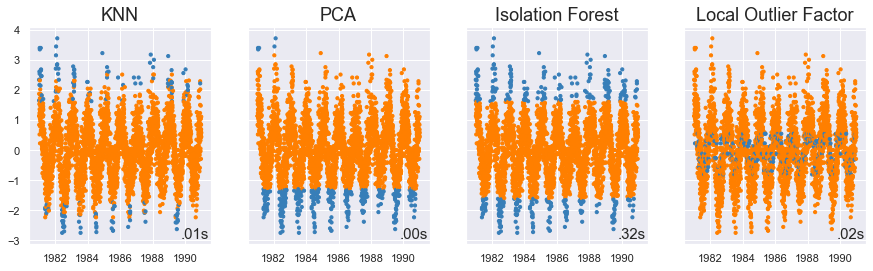

```python
matplotlib.rcParams['contour.negative_linestyle'] = 'solid'

warnings.filterwarnings("ignore")
# Define datasets 2
X= pd.DataFrame(preprocessing.scale(dataTemp['Temp']).reshape(-1, 1))

# définir les méthodes de détection des valeurs aberrantes/anomalies à comparer
anomaly_algorithms = [
    ("KNN", KNN()),
    ("PCA", PCA(random_state=42)),
    ("Isolation Forest", IsolationForest(behaviour='new',
                                         random_state=42)),
    ("Local Outlier Factor", LocalOutlierFactor(
        n_neighbors=35))]

# Compare given classifiers under given settings
xx, yy = np.meshgrid(np.linspace(-5, 5, 150),
                     np.linspace(-5, 5, 150))

# Definition des variables
rng = np.random.RandomState(42)
i_dataset=0  # variable intermédiare
fig, ax = plt.subplots(1, 4, sharex=True, sharey=True,figsize=(15,4))
nu=0   # variable intermédiare
plot_num = 1 ## index pour les figures
pre=pd.DataFrame([]) ## pre est un cadre de données contenant des prédictions pour TOUTES les 4 méthodess
pred=pd.DataFrame([]) ## pred contient des prédictions pour chaque méthode

for name, algorithm in anomaly_algorithms:
    t0 = time.time()
    algorithm.fit(X)
    t1 = time.time()
    if i_dataset == 0:
        ax[plot_num-1].set_title(name, size=18)

    # fit the data and tag outliers
    if name == "Local Outlier Factor":
        y_pred = algorithm.fit_predict(X)
    else:
        y_pred = algorithm.fit(X).predict(X)
    if name in ["PCA","KNN"]:
        y_pred=np.reshape([1 if x==0 else -1 for x in y_pred],-1) # map 0 to 1, 1to -1 and reshape it to 1D array


#   Looking at what they have in common
    predy= dataTemp[y_pred==-1].index   # take the prediction for countries
    if name in ["PCA","KNN"]:
        predy= dataTemp[y_pred==-1].index # PCA puts label 1 for oultier, then

    if nu == 1:
        pred= list(set(predy)& set(pred))#[x for x in predy if x in predn]
    if nu==0:
        pred=predy
    nu=1
    colors = np.array(['#377eb8', '#ff7f00'])
    y_pred[y_pred==0]=-1
    ax[plot_num-1].scatter(dataTemp.index,X, s=10,color=colors[(y_pred + 1) // 2])
    ax[plot_num-1].text(.99, .01, ('%.2fs' % (t1 - t0)).lstrip('0'), verticalalignment='bottom', size=15,
            transform=ax[plot_num-1].transAxes, horizontalalignment='right')
    plot_num += 1
    pre[name]=y_pred #pre.append(y_pred)
print('Liste des éléments sélectionnés comme aberrants par toutes les méthodes  sont \n')
print(pred,'\n')

plt.savefig('Temp2.png',dpi=200)
plt.show()
```

### Commentaires

Ces figures montre les résultats de quatre méthodes **PCA, IsolationForest, LOF and KNN** sur cette donnée. La **couleur orange** signifie **normale** et **anormale** pour la couleur bleue. Les données sont normalisées en amont. **KNN** donne un meilleur résultat par rapport aux autres. Il parvient à detecter les températures **hautes et basses**. Cependant, les autres méthodes en détectent quelques unes mais elles génèrent beaucoup d'erreurs. **LOF**, malgré sa popularité, donne un résultat complètement erroné sur ces données.

## Dataset 5: Sale transactions

[ go back to the top ]

cet ensemble de données contient des informations concernant les ventes et les produits de **salespersonnel** d'une certaine société. Les vendeurs fixent leurs propres prix de vente et rapportent les ventes à l'entreprise à la fin de chaque mois. Un faible pourcentage de ces enregistrements a été vérifié et étiqueté comme **"ok" ou "fraud"**. Il s'agit de transactions de 387010, avec 5 variables. Après le prétraitement et l'élimination des valeurs manquantes, les observations de $15546$ sont conservées pour une analyse plus approfondie, avec $1199$ transactions frauduleuses, soit $7 \%$. Il s'agit d'un problème d'apprentissage supervisé, l'objectif est d'entrainer le modèle à identifier correctement les **transactions frauduleuses et non frauduleuses** et de prédire le résultat pour les transactions restantes. Les données sont disponibles dans le **package "DMwR" dans R.**

```python
from pandas import read_csv
from matplotlib import pyplot
sales = read_csv('sales.csv', header=0, squeeze=True).drop([ 'Unnamed: 0'],axis=1).dropna(axis=0) # importer les donnèes
print(sales) #les afficher
print(sales[sales.isnull().any(axis=1)]) # imprimer  les NAs
```

```
           ID   Prod    Quant      Val  Insp
0          v1     p1    182.0   1665.0  unkn
1          v2     p1   3072.0   8780.0  unkn
2          v3     p1  20393.0  76990.0  unkn
3          v4     p1    112.0   1100.0  unkn
4          v3     p1   6164.0  20260.0  unkn
...       ...    ...      ...      ...   ...
401141  v5918  p4126    113.0   9330.0  unkn
401142  v2540  p4126    118.0   3355.0  unkn
401143  v5896  p4127    143.0   1835.0  unkn
401144  v1796  p4127    102.0   1445.0  unkn
401145  v2540  p4127    106.0   1275.0  unkn

[387010 rows x 5 columns]
Empty DataFrame
Columns: [ID, Prod, Quant, Val, Insp]
Index: []
```

## On applique la log transformation

[ go back to the top ]

```python
sales[['Quant','Val']]=np.log(sales[['Quant','Val']]) # log transformation
sales[sales.isnull().any(axis=1)].sum()
```

```
ID       0.0
Prod     0.0
Quant    0.0
Val      0.0
Insp     0.0
dtype: float64
```

## Suppression des transactions inconnues

```python
sales1=sales.copy()
sales1=sales1[sales1.Insp!='unkn']  #
print(sales.shape)    # imprimer la dimension
sales=sales.dropna(axis=0) # Suppression des transactions manquantes (NAs)
```

```
(387010, 5)
```

## Graph des nuages de points

[ go back to the top ]

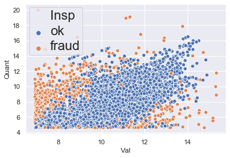

```python
import seaborn as sns; sns.set()

ax = sns.scatterplot(x="Val", y="Quant",hue="Insp",data=sales1)
plt.setp(ax.get_legend().get_texts(), fontsize='22') # for legend text
plt.setp(ax.get_legend().get_title(), fontsize='32')
plt.savefig('salescatter1.png',dpi=200)
```

## Transformatio des les étiquettes (labels): 1=ok et -1=fraude

[ go back to the top ]

```python
sales1.replace({"Insp": {"ok": 1, "fraud": -1}},inplace=True)
sales1.head()
```

|  | ID | Prod | Quant | Val | Insp |
| --- | --- | --- | --- | --- | --- |
| 48 | v42 | p11 | 10.841481 | 12.646841 | 1 |
| 51 | v45 | p11 | 5.560682 | 7.562681 | 1 |
| 63 | v42 | p11 | 10.845095 | 12.538142 | 1 |
| 72 | v50 | p11 | 10.755837 | 12.547834 | 1 |
| 77 | v46 | p12 | 6.163315 | 7.863267 | 1 |

## Application d'algorithmes de détection

[ go back to the top ]

```
Liste des éléments (ID) sélectionnés comme aberrants par toutes les méthodes  sont

['v5030', 'v4539', 'v976', 'v1149', 'v5843', 'v5594', 'v4599', 'v3930', 'v1861', 'v2270', 'v5713', 'v214', 'v4520', 'v472', 'v420', 'v1756', 'v3912', 'v1313', 'v3899', 'v884', 'v1200', 'v2725', 'v3467', 'v662', 'v1033', 'v523', 'v4782', 'v516', 'v876', 'v2425', 'v1239', 'v672', 'v1435', 'v1201', 'v5…
```

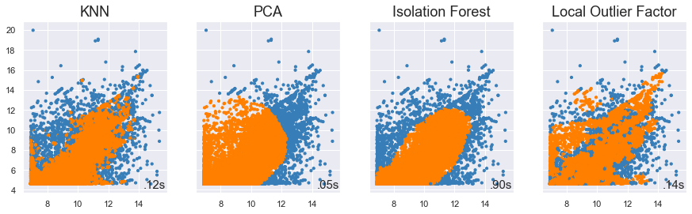

```python
matplotlib.rcParams['contour.negative_linestyle'] = 'solid'

warnings.filterwarnings("ignore")
X= pd.DataFrame(sales1[['Quant','Val']])

outliers_fraction=0.077 # la proportion des valeurs aberrantes.

# définir les méthodes de détection des valeurs aberrantes/anomalies à comparer
anomaly_algorithms = [
    ("KNN", KNN()),
    ("PCA", PCA(random_state=42)),
    ("Isolation Forest", IsolationForest(behaviour='new',
                                         random_state=42)),
    ("Local Outlier Factor", LocalOutlierFactor(
        n_neighbors=35))]

# Compare given classifiers under given settings
xx, yy = np.meshgrid(np.linspace(-5, 5, 150),
                     np.linspace(-5, 5, 150))

# Definition des variables
rng = np.random.RandomState(42)
i_dataset=0  # variable intermédiare
fig, ax = plt.subplots(1, 4, sharex=True, sharey=True,figsize=(15,4))
nu=0   # variable intermédiare
plot_num = 1 ## index pour les figures
pre=pd.DataFrame([]) ## pre est un cadre de données contenant des prédictions pour TOUTES les 4 méthodess
pred=pd.DataFrame([]) ## pred contient des prédictions pour chaque méthode

for name, algorithm in anomaly_algorithms:
    t0 = time.time()
    algorithm.fit(X)
    t1 = time.time()
    if i_dataset == 0:
        ax[plot_num-1].set_title(name, size=18)
    # fit the data and tag outliers
    if name == "Local Outlier Factor":
        y_pred = algorithm.fit_predict(X)
    else:
        y_pred = algorithm.fit(X).predict(X)
    if name in ["PCA","KNN"]:
        y_pred=np.reshape([1 if x==0 else -1 for x in y_pred],-1) # map 0 to 1, 1to -1 and reshape it to 1D array

#   Looking at what they have in common
    predy= sales1[y_pred==-1].iloc[:,0]   # take the prediction for countries
    if name in ["PCA","KNN"]:
        predy= sales1[y_pred==-1].iloc[:,0] # PCA puts label 1 for oultier, then

    if nu == 1:
        pred= list(set(predy)& set(pred))#[x for x in predy if x in predn]
    if nu==0:
        pred=predy
    #print('aldo',nu,'\n',predy,'\n')
    nu=1
    colors = np.array(['#377eb8', '#ff7f00'])
    y_pred[y_pred==0]=-1
    #y_pred.sort()
    ax[plot_num-1].scatter(X.iloc[:, 1], X.iloc[:, 0], s=10,color=colors[(y_pred + 1) // 2])
    ax[plot_num-1].text(.99, .01, ('%.2fs' % (t1 - t0)).lstrip('0'), verticalalignment='bottom', size=15,
            transform=ax[plot_num-1].transAxes, horizontalalignment='right')
    plot_num += 1
    pre[name]=y_pred#pre.append(y_pred)
print('Liste des éléments (ID) sélectionnés comme aberrants par toutes les méthodes  sont \n')
print(pred,'\n')

plt.savefig('sale_algo.png',dpi=200)
plt.show()
```

## Proportion des valeurs aberrantes

```python
1199/15546
```

```
0.07712594879711823
```

## La courbe ROC

[ go back to the top ]

**ROC (de l’anglais receiver operating characteristic, pour « caractéristique de fonctionnement du récepteur »)** dite aussi caractéristique de performance (d'un test) ou courbe sensibilité/spécificité, est une mesure de la performance d'un classificateur binaire. Graphiquement, on représente souvent la mesure ROC sous la forme d'une courbe qui donne le taux de vrais positifs (fraction des positifs qui sont effectivement détectés) en fonction du taux de faux positifs (fraction des négatifs qui sont incorrectement détectés).

```
Les quatres méthodes

KNN
PCA
Isolation Forest
Local Outlier Factor
```

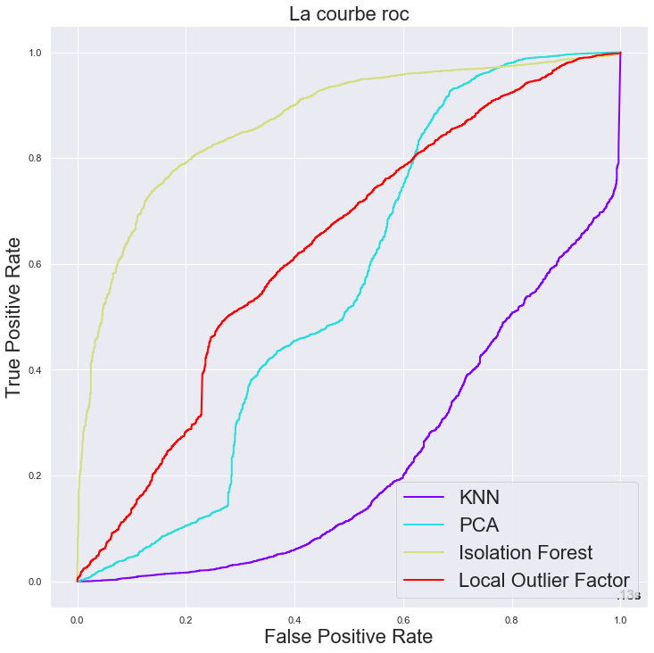

```python
from matplotlib.pyplot import cm   # for coloring
from sklearn.metrics import roc_curve

# Compare given classifiers under given settings
plt.subplots_adjust(left=.02, right=.98, bottom=.001, top=.96, wspace=.05,
                    hspace=.01)
plt.figure(figsize=(12, 12))   # create subplots


from sklearn.ensemble import IsolationForest
outliers_fraction=0.077
#for i_dataset, X in enumerate(datasets):
c=cm.rainbow(np.linspace(0,1,len(anomaly_algorithms)))
num=1
y=sales1['Insp']
Allpre=pred=pd.DataFrame([])
X= pd.DataFrame(sales1[['Quant','Val']])
anomaly_algorithms = [
   ("KNN", KNN(contamination=outliers_fraction)),
    ("PCA", PCA(random_state=42, contamination=outliers_fraction)),
    ("Isolation Forest", IsolationForest(behaviour='new', contamination=outliers_fraction,
                                         random_state=42)),
  ("Local Outlier Factor", LocalOutlierFactor(
        n_neighbors=35,novelty=True, contamination=outliers_fraction))]
print('Les quatres méthodes\n')
for cc, [name, algorithm] in zip(c, anomaly_algorithms):
        print(name)
        algorithm.fit(X)
        if name in ["KNN","PCA"]:
            y_pred = algorithm.decision_scores_#algorithm.negative_outlier_factor_
        else:
            y_pred = algorithm.score_samples(X)
        Allpre[name]=y_pred
        fpr1, tpr1, thresholds1 = roc_curve(y,y_pred)
        plt.plot(fpr1, tpr1,color=cc, lw=2,label=name)
        plt.legend(fontsize=22)
        plt.xlabel('False Positive Rate',fontsize=22)
        plt.ylabel('True Positive Rate',fontsize=22)
        plt.title('La courbe roc',fontsize=22)
        plt.text(.99, .01, ('%.2fs' % (t1 - t0)).lstrip('0'), verticalalignment='bottom', size=15,
            transform=plt.gca().transAxes, horizontalalignment='right')

num+=1
plt.savefig('sales_roc.png',dpi=200)
plt.show()
```

## Trouver AUC : Surface sous la courbe

[ go back to the top ]

**L'Aire sous la courbe ROC ou (AUC)** c'est un outil visuel pour mesurer la performence des modèles et de les comparer. Un test **parfait** correspond à une **aire (surface)** de $1$ tandis qu'un test **mauvais** correspond à une **aire (surface)** de $0,5$. Un guide pour la classification est donné par le système de points:

```
- .90-1 = * très bon (A)* ;
- .80-.90  *bon (B)*;
- .70-.80 = *raisonnable (C)*;
- .60-.70 = *faible (D)*
- .50-.60 = *échoué (F)*
```

```python
# calculate scores
from sklearn.metrics import roc_auc_score
KNN_auc = roc_auc_score(y, Allpre['KNN'])
LOF_auc = roc_auc_score(y, Allpre['Local Outlier Factor'])
PCA_auc = roc_auc_score(y, Allpre['PCA'])
IsoFort_auc = roc_auc_score(y, Allpre['Isolation Forest'])
# summarize scores
print('KNN: ROC AUC=%.3f' % (KNN_auc))
print('LOF: ROC AUC=%.3f' % (LOF_auc))
print('PCA: ROC AUC=%.3f' % (PCA_auc))
print('IsoFort: ROC AUC=%.3f' % (IsoFort_auc))
```

```
KNN: ROC AUC=0.228
LOF: ROC AUC=0.632
PCA: ROC AUC=0.557
IsoFort: ROC AUC=0.870
```

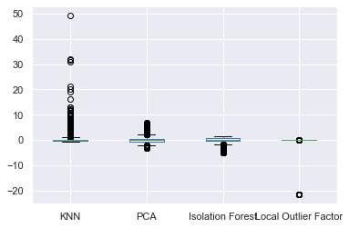

```python
res=pd.DataFrame(preprocessing.scale(Allpre)) # la normalisation
res.columns=Allpre.columns
res.boxplot() # la boite à moustaches.
plt.savefig('sales_boxplot.png',dpi=200)
```

## Quelques mesures

[ go back to the top ]

Pour évaluer la performance des modèle, ces quantités sont prises en compte : **Sensibilité, Rappel, ou taux de vrais positifs ; Spécificité ou taux de vrais négatifs ; Précision ou valeur prédictive positive ; Valeur prédictive négative ; Taux de faux positifs ; Taux de faux négatifs ; Taux de fausse découverte ; Accuracy**

```python
from sklearn.metrics import confusion_matrix
for name in pre:
        print('\n\n For ', name,'Algorithm')
        TN,FP,FN,TP=confusion_matrix(y, pre[name]).ravel()
        # Sensitivity, recall, or true positive rate
        TPR = TP/(TP+FN)
        print('Sensitivity recall\n ',TPR)
        # Specificity or true negative rate
        TNR = TN/(TN+FP)
        print('pecificity or true negative rate\n ',TNR)
        # Precision or positive predictive value
        PPV = TP/(TP+FP)
        print('Precision or positive predictive value \n',PPV)

        # Negative predictive value
        NPV = TN/(TN+FN)
        print('Negative predictive value \n',NPV)

        # False positive rate
        FPR = FP/(FP+TN)
        print('False positive rate \n',FPR)

        # False negative rate
        FNR = FN/(TP+FN)
        print('False negative rate \n',FNR)

        # False discovery rate
        FDR = FP/(TP+FP)
        print('False discovery rate \n',FDR)

        # Overall accuracy
        ACC = (TP+TN)/(TP+FP+FN+TN)
        print('Overall accuracy \n',ACC)
```

```
 For  KNN Algorithm
Sensitivity recall
  0.9463302432564299
pecificity or true negative rate
  0.377814845704754
Precision or positive predictive value
 0.9479159393981708
Negative predictive value
 0.3704006541291905
False positive rate
 0.622185154295246
False negative rate
 0.053669756743570086
False discovery rate
 0.05208406060182923
Overall accuracy
 0.9024829538144861


 For  PCA Algorithm
Sensitivity recall
  0.9063218791384958
pecificity or true negative rate
  0.17597998331943285
Precision or positive predictive value
 0.9293831748981488
Negative predictive value
 0.13569131832797426
False positive rate
 0.8240200166805671
False negative rate
 0.09367812086150415
False discovery rate
 0.07061682510185119
Overall accuracy
 0.8499935674771646


 For  Isolation Forest Algorithm
Sensitivity recall
```

[output cut: 19 more lines]

```
  0.9100857322088242
pecificity or true negative rate
  0.22101751459549623
Precision or positive predictive value
 0.9332427989421771
Negative predictive value
 0.17041800643086816
False positive rate
 0.7789824854045038
False negative rate
 0.08991426779117585
False discovery rate
 0.06675720105782289
Overall accuracy
 0.8569406921394571
```

## Matrice de confusion

[ go back to the top ]

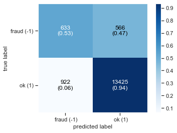

```python
from mlxtend.plotting import plot_confusion_matrix
import matplotlib.pyplot as plt
import numpy as np

binary = confusion_matrix(y, pre['Isolation Forest'])
class_names = ['ok', 'fraud']
fig, ax = plot_confusion_matrix(conf_mat=binary,
                               colorbar=True,
                                show_normed=True#,hide_spines=False,
                               )
ax.set_xticklabels(['', ' fraud (-1)', ' ok (1)'])
ax.set_yticklabels(['', 'fraud (-1)', ' ok (1)']);
plt.savefig('sales_confusionmat.png',dpi=200)
plt.show()
```

## Conclusion

[ go back to the top ]

La detection des anomalies et l'analyse des valeurs aberrantes est un domaine vaste et intéressant. Il existe un plusieurs algorithmes traitant la detection des **observations atypiques**. Cenpendant, seulement 4 méthodes ont été utilisèes dans cette étude. Les étudiants peuvent toutefois essayer les autres méthodes.

A travers une étude extensive sur une série de données réelles des différentes approches non-supervisées et supervisées de quelques méthodes classiques a permis de comprendre les **atouts et limites** ces méthodes. Il est donc important de savoir **qu'il n'existe pas de méthode parfaite dominante pour tous les ensembles de données**, en fait, elles dépendent plutôt des **données et du domaine d'application**. Cependant, certaines sont utiles. **George Box** a dit: *"Tous les modèles sont faux mais certains sont utiles”*. La question à poser est :**"A quel point doivent-ils être mauvais pour ne pas être utile”**.